# Metadata Management - Code Demonstration

Karthikeyan Chokappa (KC)

2021-04-23

## Problem Statement

Demonstrate code to monitor the Metadata Management Service Level Objective (SLO) related to Data Governance.

## Assumption

Data Governance score for each field or parameter is calculated based on various criteria for each data types. Data goodness is represented between 0.001 to 0.999, where 0.001 is low quality and 0.999 is high quality data, whereas values 0 and 1 represent anomalous data. For some typical data types the data goodness is estimated as follows,

- Numeric - Percentage of good data values is estimated by marking “NULL” or Outliers (Estimated using Box-plot method from the last 7 days) as bad data
- String - Percentage of good data values is estimated by marking “NULL” or values with highest proportion of special characters as bad data

## Metadata Governance Monitoring Method

## Pipeline Code Demonstration

### Load Packages / Libraries

```r
library(qicharts2)
```

### Define Constants

```r
pp_wrkdir <- getwd()
```

### Load Simulated Governance Data (with Failures Injected)

```r
#Simulation - Parameters
Transactions_Count            <- 1000
Transactions_DefectsInPPM_Avg <- 178
Transactions_DefectsInPPM_Std <- 19

#Simulation - Data
Transactions <- rpois(30, lambda = Transactions_Count)
DefectsInPPM <- round(rnorm(30,
                            mean = Transactions_DefectsInPPM_Avg,
                            sd   = Transactions_DefectsInPPM_Std))
Date         <- seq(as.Date('2021-01-01'),length.out = 30, by = 'day')
dbGovernance <- data.frame(Date, Transactions, DefectsInPPM)

#Simulation - Failures Injected
dbGovernance$DefectsInPPM[11] <- 255
```

### Monitor Governance Quality using Individual Control Chart

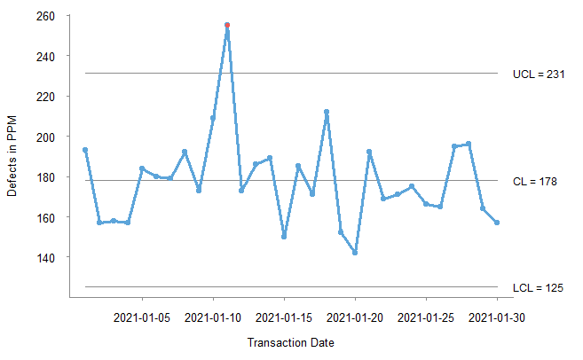

```r
# Plot I-Chart of Governance
qicharts::qic(y = dbGovernance$DefectsInPPM,
              x = dbGovernance$Date,
               chart = 'i',
               main  = 'Data Governance (I-Chart)',
    ylab  = 'Defects in PPM',
    xlab  = 'Transaction Date')
```

# Summary

The above is just sample representation demonstrating a typical monitoring mechanism for Metadata Governance information over daily transactions. This information can be pulled for all parameters for all databases across any given application. Using anomaly or defect aggregation method the overall health score of data platforms can be monitored and alerts sent if the health score / index degrades significantly.